# Ghanadan_Lab4

Linus Ghanadan

2024-02-06

## Lab 4: Fire and Tree Mortality

The database we’ll be working with today includes 36066 observations of individual trees involved in prescribed fires and wildfires occurring over 35 years, from 1981 to 2016. It is a subset of a larger fire and tree mortality database from the US Forest Service (see data description for the full database here: [link](https://www.nature.com/articles/s41597-020-0522-7#Sec10)). Our goal today is to predict the likelihood of tree mortality after a fire.

### Data Exploration

Outcome variable: *yr1status* = tree status (0=alive, 1=dead) assessed one year post-fire.

Predictors: *YrFireName, Species, Genus_species, DBH_cm, CVS_percent, BCHM_m, BTL* (Information on these variables available in the database metadata ([link](https://www.fs.usda.gov/rds/archive/products/RDS-2020-0001-2/_metadata_RDS-2020-0001-2.html))).

> Question 1: Recode all the predictors to a zero_based integer form

```r
# specify a recipe
trees_recipe <- trees_dat %>%
  recipe(yr1status ~ .) %>%
  step_integer(all_string(), zero_based = TRUE) %>%
  prep()

# bake recipe
trees_baked <- bake(trees_recipe, new_data = trees_dat)
```

### Data Splitting

> Question 2: Create trees_training (70%) and trees_test (30%) splits for the modeling

```r
# create training (70%) and test (30%) sets for the trees data
set.seed(123)  # for reproducibility
trees_split <- initial_split(trees_baked, prop = .70)
trees_baked_train <- training(trees_split)
trees_baked_test  <- testing(trees_split)
```

> Question 3: How many observations are we using for training with this split?

```r
# compute training observations
nrow(trees_baked_train)
```

```
## [1] 25246
```

There are 25246 observations in our training data.

### Simple Logistic Regression

Let’s start our modeling effort with some simple models: one predictor and one outcome each.

> Question 4: Choose the three predictors that most highly correlate with our outcome variable for further investigation.

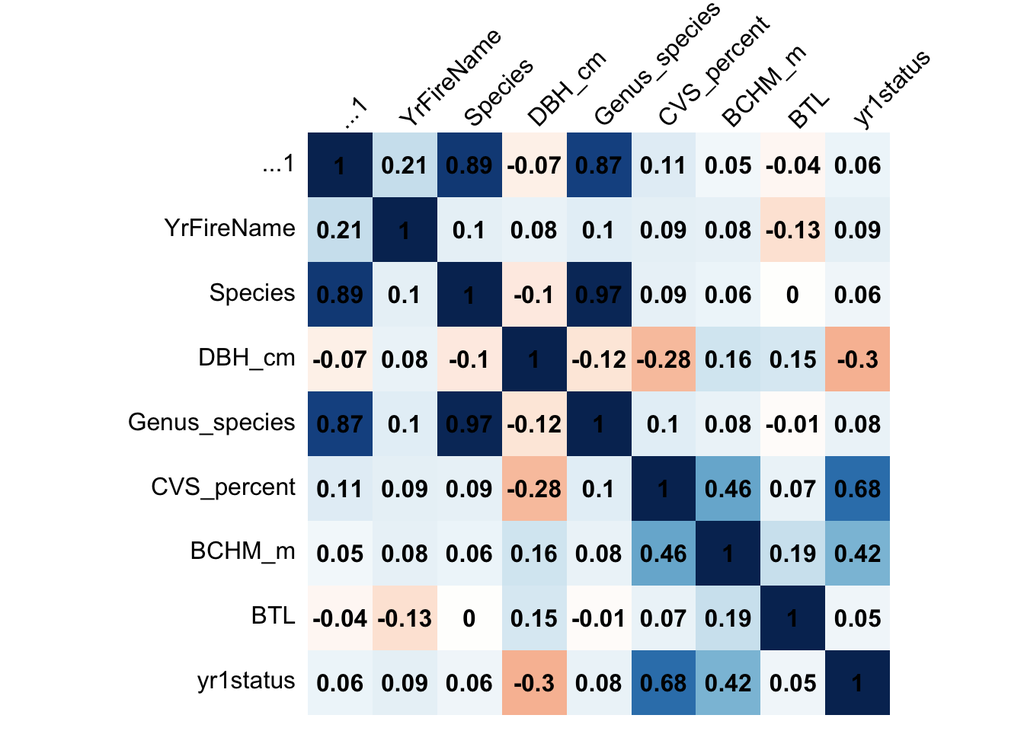

```r
# Obtain correlation matrix
corr_mat <- cor(trees_baked_train)

# Make a correlation plot between the variables
corrplot(corr_mat, method = "shade", shade.col = NA, tl.col = "black", tl.srt = 45, addCoef.col = "black", cl.pos = "n", order = "original")
```

The three variables most correlated with *yr1status* are *CVS_percent* (0.68), *BCHM_m* (0.42), and *DBH_cm* (-0.3).

> Question 5: Use glm() to fit three simple logistic regression models, one for each of the predictors you identified.

```r
# Build model for CVS_percent
model_cvs <- glm(data = trees_baked_train, yr1status ~ CVS_percent, family = "binomial")

# Build model for BCHM_m
model_bchm <- glm(data = trees_baked_train, yr1status ~ BCHM_m, family = "binomial")

# Build model for DBH_cm
model_dbh <- glm(data = trees_baked_train, yr1status ~ DBH_cm, family = "binomial")

# tidy models
tidy(model_cvs)
```

```
## # A tibble: 2 × 5
##   term        estimate std.error statistic p.value
##   <chr>          <dbl>     <dbl>     <dbl>   <dbl>
## 1 (Intercept)  -6.61     0.111       -59.4       0
## 2 CVS_percent   0.0762   0.00122      62.7       0
```

```r
tidy(model_bchm)
```

```
## # A tibble: 2 × 5
##   term        estimate std.error statistic p.value
##   <chr>          <dbl>     <dbl>     <dbl>   <dbl>
## 1 (Intercept)   -1.86    0.0227      -81.9       0
## 2 BCHM_m         0.211   0.00379      55.8       0
```

```r
tidy(model_dbh)
```

```
## # A tibble: 2 × 5
##   term        estimate std.error statistic  p.value
##   <chr>          <dbl>     <dbl>     <dbl>    <dbl>
## 1 (Intercept)   0.546    0.0318       17.2 4.55e-66
## 2 DBH_cm       -0.0598   0.00128     -46.7 0
```

```r
# exponentiate the coefficients from model objects for interpretation, giving changes in odds of tree being dead one year after fire
exp(coef(model_cvs))
```

```
## (Intercept) CVS_percent
## 0.001341998 1.079220197
```

```r
exp(coef(model_bchm))
```

```
## (Intercept)      BCHM_m
##   0.1551401   1.2353812
```

```r
exp(coef(model_dbh))
```

```
## (Intercept)      DBH_cm
##   1.7257194   0.9419895
```

### Interpret the Coefficients

We aren’t always interested in or able to interpret the model coefficients in a machine learning task. Often predictive accuracy is all we care about.

> Question 6: That said, take a stab at interpreting our model coefficients now.

The odds of a tree being dead one year after a fire multiply 1.08-fold for every 1 additional percent of crown volume that was scorched.

The odds of a tree being dead one year after a fire multiply 1.235-fold for every 1 additional meter of vertical height with maximum bark char.

The odds of a tree being dead one year after a fire multiply 0.94-fold for every 1 additional centimeter in diameter at breast height.

> Question 7: Now let’s visualize the results from these models. Plot the fit to the training data of each model.

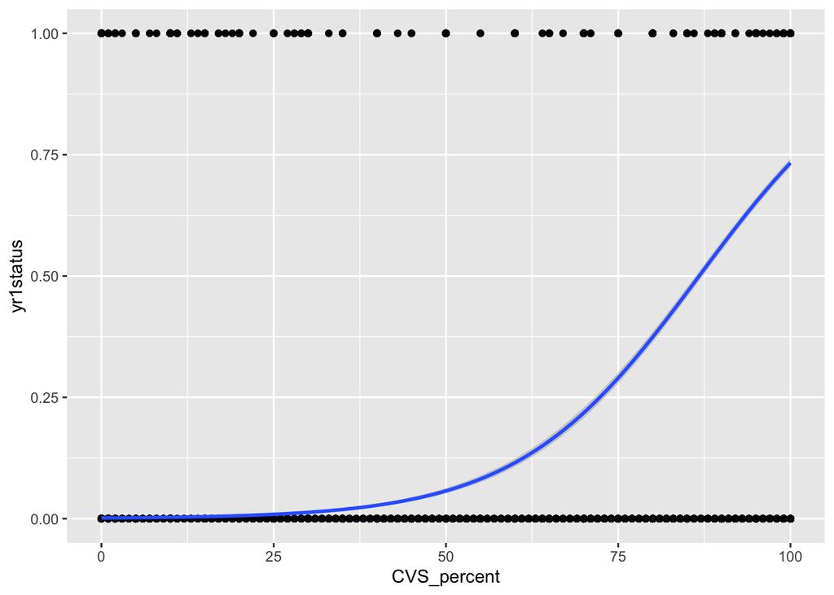

```r
# Plot CVS model with training data
ggplot(trees_baked_train, aes(x = CVS_percent, y = yr1status)) +
  geom_point() +
  stat_smooth(method = "glm", se = TRUE, method.args = list(family = "binomial"))
```

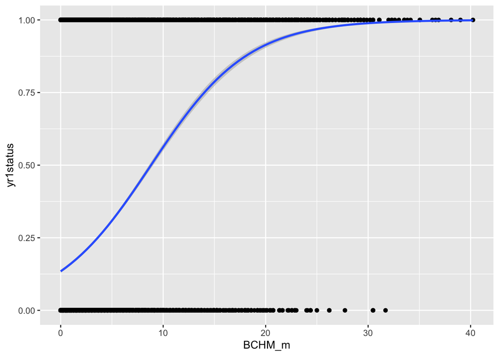

```r
# Plot BCHM model with training data
ggplot(trees_baked_train, aes(x = BCHM_m, y = yr1status)) +
  geom_point() +
  stat_smooth(method = "glm", se = TRUE, method.args = list(family = "binomial"))
```

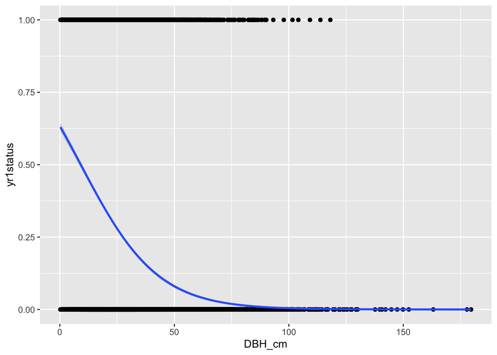

```r
# Plot DBH model with training data
ggplot(trees_baked_train, aes(x = DBH_cm, y = yr1status)) +
  geom_point() +
  stat_smooth(method = "glm", se = TRUE, method.args = list(family = "binomial"))
```

### Multiple Logistic Regression

Let’s not limit ourselves to a single-predictor model. More predictors might lead to better model performance.

> Question 8: Use glm() to fit a multiple logistic regression called “logistic_full”, with all three of the predictors included. Which of these are significant in the resulting model?

```r
# build multiple logistic regression model with all three predictors
logistic_full <- glm(yr1status ~ CVS_percent + BCHM_m + DBH_cm, family = "binomial", data = trees_baked_train)

# tidy model
tidy(logistic_full)
```

```
## # A tibble: 4 × 5
##   term        estimate std.error statistic   p.value
##   <chr>          <dbl>     <dbl>     <dbl>     <dbl>
## 1 (Intercept)  -4.76     0.115       -41.3 0
## 2 CVS_percent   0.0615   0.00118      52.2 0
## 3 BCHM_m        0.159    0.00544      29.3 7.54e-189
## 4 DBH_cm       -0.0607   0.00195     -31.2 6.84e-214
```

All three predictors are statistically significant at alpha level 0.01.

### Estimate Model Accuracy

Now we want to estimate our model’s generalizability using resampling.

> Question 9: Use cross validation to assess model accuracy. Use caret::train() to fit four 10-fold cross-validated models (cv_model1, cv_model2, cv_model3, cv_model4) that correspond to each of the four models we’ve fit so far: three simple logistic regression models corresponding to each of the three key predictors (CVS_percent, DBH_cm, BCHM_m) and a multiple logistic regression model that combines all three predictors.

```r
# Convert outcome variable to factor
trees_baked_train$yr1status <- as.factor(trees_baked_train$yr1status)

# Define control parameters for 10-fold CV
ctrl <- trainControl(method = "cv", number = 10)

# Create formula for each model
formula1 <- as.formula("yr1status ~ CVS_percent")
formula2 <- as.formula("yr1status ~ DBH_cm")
formula3 <- as.formula("yr1status ~ BCHM_m")
formula4 <- as.formula("yr1status ~ CVS_percent + DBH_cm + BCHM_m")

# Fit CV models
cv_model1 <- train(formula1, data = trees_baked_train, method = "glm", trControl = ctrl, family = "binomial")
cv_model2 <- train(formula2, data = trees_baked_train, method = "glm", trControl = ctrl, family = "binomial")
cv_model3 <- train(formula3, data = trees_baked_train, method = "glm", trControl = ctrl, family = "binomial")
cv_model4 <- train(formula4, data = trees_baked_train, method = "glm", trControl = ctrl, family = "binomial")

# Print results
print(cv_model1)
```

```
## Generalized Linear Model
##
## 25246 samples
##     1 predictor
##     2 classes: '0', '1'
##
## No pre-processing
## Resampling: Cross-Validated (10 fold)
## Summary of sample sizes: 22721, 22722, 22722, 22721, 22721, 22721, ...
## Resampling results:
##
##   Accuracy   Kappa
##   0.8975291  0.7638933
```

```r
print(cv_model2)
```

```
## Generalized Linear Model
##
## 25246 samples
##     1 predictor
##     2 classes: '0', '1'
##
## No pre-processing
## Resampling: Cross-Validated (10 fold)
## Summary of sample sizes: 22721, 22722, 22721, 22721, 22721, 22722, ...
## Resampling results:
##
##   Accuracy   Kappa
##   0.7513669  0.215248
```

```r
print(cv_model3)
```

```
## Generalized Linear Model
##
## 25246 samples
##     1 predictor
##     2 classes: '0', '1'
##
## No pre-processing
## Resampling: Cross-Validated (10 fold)
## Summary of sample sizes: 22721, 22721, 22722, 22722, 22721, 22722, ...
## Resampling results:
##
##   Accuracy   Kappa
##   0.7722419  0.3286864
```

```r
print(cv_model4)
```

```
## Generalized Linear Model
##
## 25246 samples
##     3 predictor
##     2 classes: '0', '1'
##
## No pre-processing
## Resampling: Cross-Validated (10 fold)
## Summary of sample sizes: 22721, 22721, 22721, 22722, 22721, 22722, ...
## Resampling results:
##
##   Accuracy   Kappa
##   0.9041038  0.7707446
```

> Question 10: Use caret::resamples() to extract then compare the classification accuracy for each model. (Hint: resamples() wont give you what you need unless you convert the outcome variable to factor form). Which model has the highest accuracy?

```r
# Create list of models
models_list <- list(cv_model1, cv_model2, cv_model3, cv_model4)

# Use resamples() to compare classification accuracy
resamp <- resamples(models_list)
summary(resamp)
```

```
##
## Call:
## summary.resamples(object = resamp)
##
## Models: Model1, Model2, Model3, Model4
## Number of resamples: 10
##
## Accuracy
##             Min.   1st Qu.    Median      Mean   3rd Qu.      Max. NA's
## Model1 0.8887129 0.8918708 0.8976238 0.8975291 0.9004556 0.9152139    0
## Model2 0.7461386 0.7485149 0.7516337 0.7513669 0.7541601 0.7568317    0
## Model3 0.7580198 0.7716832 0.7744109 0.7722419 0.7764683 0.7785261    0
## Model4 0.8918812 0.9009901 0.9057052 0.9041038 0.9086139 0.9104950    0
##
## Kappa
##             Min.   1st Qu.    Median      Mean   3rd Qu.      Max. NA's
## Model1 0.7445671 0.7519321 0.7646012 0.7638933 0.7704532 0.8001752    0
## Model2 0.1908528 0.2076551 0.2166206 0.2152480 0.2208098 0.2370475    0
## Model3 0.2915495 0.3269586 0.3353696 0.3286864 0.3424947 0.3442267    0
## Model4 0.7447970 0.7632744 0.7737224 0.7707446 0.7798579 0.7865700    0
```

Let’s move forward with this single most accurate model.

> Question 11: Compute the confusion matrix and overall fraction of correct predictions by the model.

```r
# Convert outcome variable to factor
trees_baked_train$yr1status <- as.factor(trees_baked_train$yr1status)

# Make predictions on training data
trees_predict_train <- predict(cv_model4, newdata = trees_baked_train)

# Convert predictions to factor with the same levels as yr1status
trees_predict_train <- factor(trees_predict_train, levels = levels(trees_baked_train$yr1status))

# Create confusion matrix
trees_confusion_matrix_train <- confusionMatrix(trees_predict_train, reference = trees_baked_train$yr1status)

# Print confusion matrix
print(trees_confusion_matrix_train)
```

```
## Confusion Matrix and Statistics
##
##           Reference
## Prediction     0     1
##          0 16527   852
##          1  1572  6295
##
##                Accuracy : 0.904
##                  95% CI : (0.9003, 0.9076)
##     No Information Rate : 0.7169
##     P-Value [Acc > NIR] : < 2.2e-16
##
##                   Kappa : 0.7705
##
##  Mcnemar's Test P-Value : < 2.2e-16
##
##             Sensitivity : 0.9131
##             Specificity : 0.8808
##          Pos Pred Value : 0.9510
##          Neg Pred Value : 0.8002
##              Prevalence : 0.7169
##          Detection Rate : 0.6546
##    Detection Prevalence : 0.6884
##       Balanced Accuracy : 0.8970
##
##        'Positive' Class : 0
##
```

```r
# Compute overall fraction of correct predictions
trees_confusion_matrix_train$overall["Accuracy"]
```

```
##  Accuracy
## 0.9039848
```

> Question 12: Explain what the confusion matrix is telling you about the types of mistakes made by logistic regression.

> Question 13: What is the overall accuracy of the model? How is this calculated?

The overall accuracy of the model is 90.4%. This is calculated as the number of correct predictions (16,527 + 6,295) divided by the total number of predictions made (25246).

### Test Final Model

Alright, now we’ll take our most accurate model and make predictions on some unseen data (the test data).

> Question 14: Now that we have identified our best model, evaluate it by running a prediction on the test data, trees_test.

```r
# Convert outcome variable to factor
trees_baked_test$yr1status <- as.factor(trees_baked_test$yr1status)

# Make predictions on test data
trees_predict_test <- predict(cv_model4, newdata = trees_baked_test)

# Convert predictions to factor with the same levels as yr1status
trees_predict_test <- factor(trees_predict_test, levels = levels(trees_baked_test$yr1status))

# Create confusion matrix
trees_confusion_matrix_test <- confusionMatrix(trees_predict_test, reference = trees_baked_test$yr1status)

# Print confusion matrix
print(trees_confusion_matrix_test)
```

```
## Confusion Matrix and Statistics
##
##           Reference
## Prediction    0    1
##          0 7032  366
##          1  702 2720
##
##                Accuracy : 0.9013
##                  95% CI : (0.8955, 0.9069)
##     No Information Rate : 0.7148
##     P-Value [Acc > NIR] : < 2.2e-16
##
##                   Kappa : 0.7656
##
##  Mcnemar's Test P-Value : < 2.2e-16
##
##             Sensitivity : 0.9092
##             Specificity : 0.8814
##          Pos Pred Value : 0.9505
##          Neg Pred Value : 0.7949
##              Prevalence : 0.7148
##          Detection Rate : 0.6499
##    Detection Prevalence : 0.6837
##       Balanced Accuracy : 0.8953
##
##        'Positive' Class : 0
##
```

```r
# Compute overall fraction of correct predictions
trees_confusion_matrix_test$overall["Accuracy"]
```

```
##  Accuracy
## 0.9012939
```

> Question 15: How does the accuracy of this final model on the test data compare to its cross validation accuracy? Do you find this to be surprising? Why or why not?